# Biometrie onderzoek

2026-04-21

Authors: Jesse Postma 507655, Robin Offringa 468620, Tristan Kruithof 508757

## Inleiding

Al jaren lang is vraag naar onderzoek tussen de verhouding van armlengte tot lichaamslengte bij mannen en vrouwen, vandaag geven wij definitief een antwoord op dit vraagstuk.

## Onderzoeksvraag

Is er een verschil tussen de verhouding van armlengte tot lichaamslengte bij mannen en vrouwen?

## Hypothese

Er is een verschil tussen de verhouding van armlengte tot lichaamslengte bij mannen en vrouwen.

## NulHypothese

Er is geen verschil tussen de verhouding van armlengte tot lichaamslengte bij mannen en vrouwen.

### Ontwerp van het experiment

#### Wat meten we?

We meten de lichaamslengte en de armlengte van elk persoon afgerond op hele centimeters.

#### Welke groepen?

We meten mannen en vrouwen als afzonderlijke groepen.

#### Hoeveel metingen?

We maken 20 metingen per groep, dus 40 samples in totaal.

### Ontwerp het protocol

#### Doel

We willen kijken of er verschil is tussen mannen en vrouwen in de verhouding tussen armlengte en lichaamslengte.

#### Wat meten we?

- lichaamslengte in cm
- armlengte in cm
- gender
- meter-ID
- subject-ID

#### Wat hebben we nodig?

- meetlint
- spreadsheet om data op te schrijven
- proefpersonen

#### Hoe meten we?

1. Geef elke proefpersoon een subject-ID.
2. Vraag of de persoon mee wil doen.
3. Meet eerst de lichaamslengte.
4. Meet daarna de armlengte.
5. Laat de arm op schouderhoogte uitstrekken.
6. Laat de tweede meter dezelfde persoon ook meten.

#### Afspraken

- Gebruik steeds dezelfde meet afspraken.
- Meet zo precies mogelijk.
- Zet geen namen in de data.
- Gebruik alleen een subject-ID.
- Wissel af zodat iedereen evenveel meet.

#### Controle

Aan het einde kijken we of alles klopt. - Zijn er genoeg metingen? - Zijn de subject-ID’s uniek? - Zitten er rare waarden tussen? - Zijn de metingen van de twee meters ongeveer gelijk?

##### Benodigdheden

1. Schuifmaat of meetlint.
2. Spreadsheet om resultaten vast te leggen, met toegang hiertoe op locaties zonder internet-toegang.
3. Je laborant-ID: een unieke *identifier* die jou als onderzoeker identificeert. Neem hiervoor je studentnummer.

##### Data verzamelen

Zoek, samen met een ander groepje van je klas, in of rond het schoolgebouw medestudenten die willen deelnemen aan het onderzoek. Leg kort uit dat jullie voor een schoolopdracht de armlengte en lichaamslengte meten en dat alle gegevens anoniem worden opgeslagen.

Is het antwoord nee, dan bedank je vriendelijk en zoek je verder. Is het antwoord ja, dan wijs je de proefpersoon een rustige plek aan waar de meting kan plaatsvinden.

Vraag de proefpersoon om:

Rechtop te gaan staan tegen een muur of meetlat, met hakken tegen de grond. Meet vervolgens de lichaamslengte in centimeters en noteer deze in de spreadsheet.

Daarna vraagt je de proefpersoon om de arm zijwaarts te strekken op schouderhoogte. Meet de armlengte van het schouderpunt (acromion) tot de pols (carpal bot pisiform), opnieuw in centimeters.

Leg beide waarden vast in de spreadsheet, samen met:

je laborant-ID,

een subject-ID (géén naam),

de sexe van de proefpersoon (m/v/anders/onbekend).

Het parallelle groepje voert dezelfde metingen uit bij dezelfde proefpersonen, zonder jullie resultaten te horen, en gebruikt daarbij dezelfde subject-ID’s.

Bedank de proefpersoon voor deelname. Wissel de metingen af tussen de laboranten in jullie groepje om meetfouten te verminderen.

Ga door totdat er voldoende gegevens zijn verzameld voor beide doelgroepen.

## Uitvoering

Je moet de onderzoeksresultaten in deze vorm opslaan:

```
gender;lengte;l arm;meter;Id
m; 190, 54, 507655, 2
m; 191, 54, 507656, 2
```

## Analyse

### Beschrijvende statistiek

Je hebt je data verzameld en ingelezen. Nu is het tijd om er een eerste verkenning op uit te voeren.

Allereerst berekenen we de lengte/arm-lengte ratio, want dat was de onderzoeksvraag. Onderstaande code voegt een extra kolom toe aan de dataframe.

```
##   gender lengte l.arm  meter Id    ratio
## 1    Man    187    50 468620  1 3.740000
## 2    Man    187    50 508757  1 3.740000
## 3    Man    196    55 508757  2 3.563636
## 4    Man    196    54 468620  2 3.629630
## 5  Vrouw    173    50 508757  3 3.460000
## 6  Vrouw    173    48 468620  3 3.604167
```

Dit geeft per subject een ratio tussen de lengte en de armlengte.

Dan kunnen we nog kijken naar de gemiddelde lengte en armlengte per gender:

```
##                Man       Vrouw
## length 184.9523810 171.1500000
## arm     51.4761905  48.5000000
## ratio    3.5983918   3.5357533
## dev      0.1763337   0.1736281
```

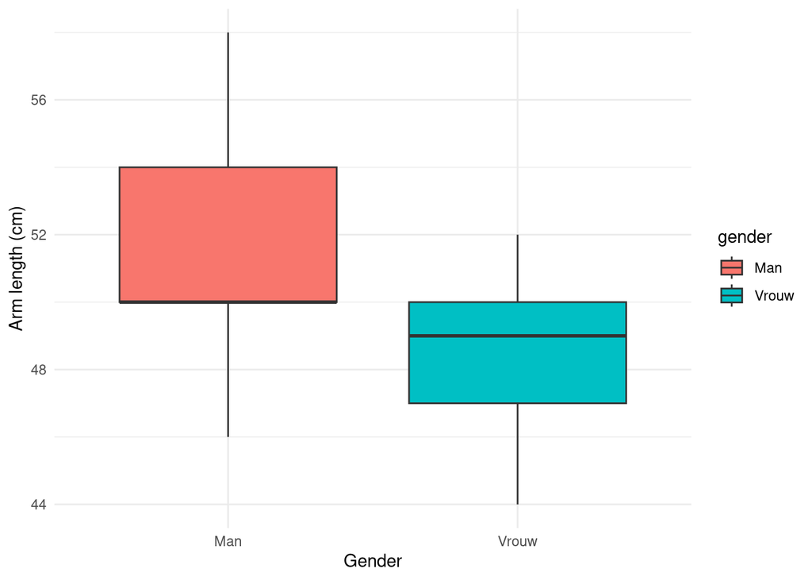

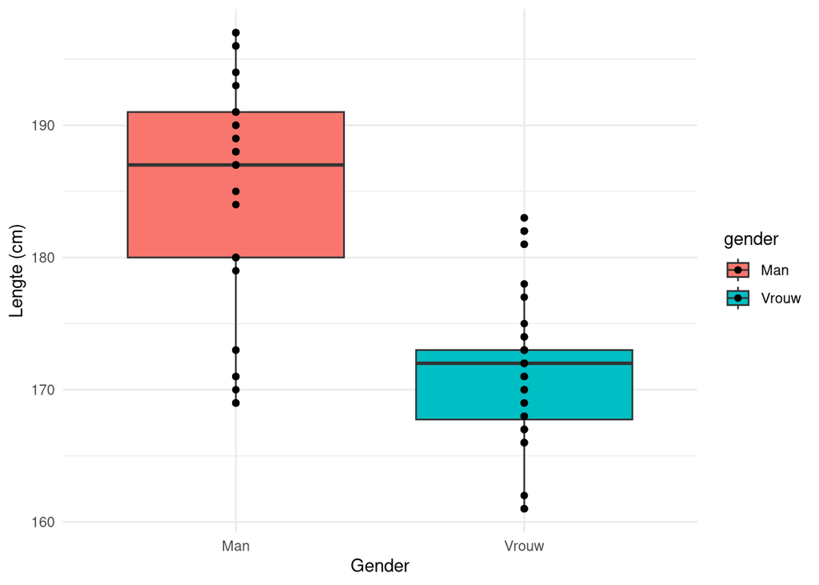

Deze plots geven weer dat er wel een degelijk verschil tussen de groepen is.

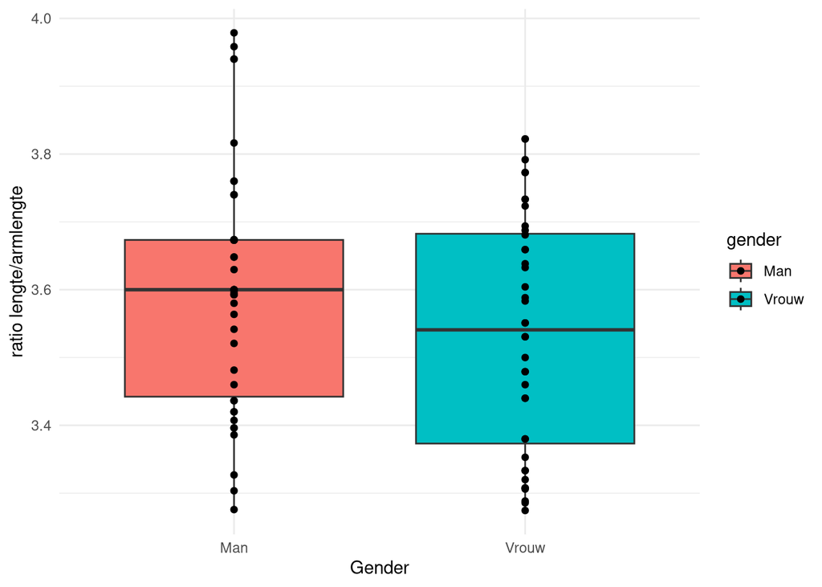

### Welke verdeling?

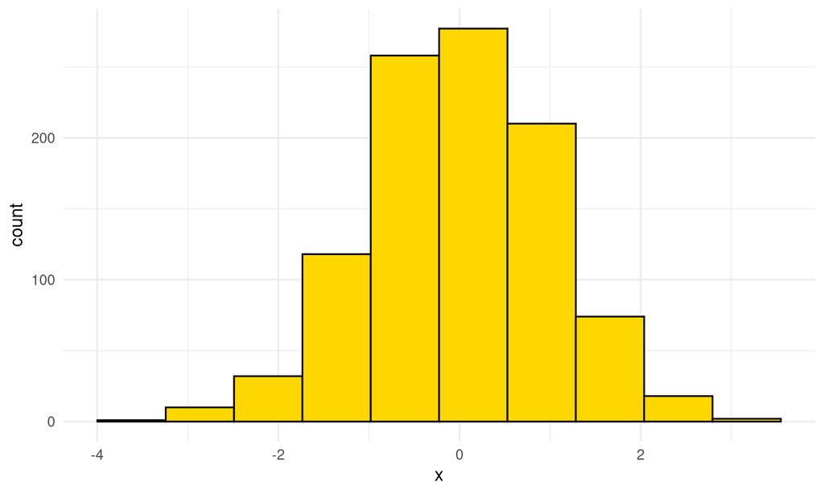

```r
hist_data <- data.frame(x = rnorm(n = 1000))
ggplot(data = hist_data,
       mapping = aes(x = x)) +
    geom_histogram(bins = 10, fill = "gold", colour = "black") +
    theme_minimal()
```

**Dit *experiment* met de argumenten van `rnorm()` en `hist()` moet je opnemen in je eigen RMarkdown.**  
Beantwoord deze vragen:

1. Wat gebeurt er met de vorm van de verdeling als `n` groter wordt? > De nauwkeurigheid van de “kleinere” assen wordt verloren.
2. Wat gebeurt er met de spreiding van de data (x-as) als `n` groter wordt, en kan je dat verklaren? > De spreiding blijft vrijwel gelijk doordat die bepaalt word door de standard deviation van de normale verdeling. Grotere n betekend alleen gladdere grafiek.
3. Waarom is bij zelfde instellingen voor `n` en `breaks` de uitkomst toch verschillend? > Omdat elke keer nieuwe data wordt gegenereerd.
4. Welke minimale `n` geeft het meeste kans om een echte normaalverdeling te zien? > Vanaf ~ n = 1000 begint er een normale distributie te verschijnen.
5. Wat voor bijzonders is er aan de hand met het `breaks` argument? Geeft de documentatie daar een verklaring voor? > Er staat dat R zelf mooie grenzen voor de bins aanneemt dus niet expliciet wat je meegeeft als variabele.

### Bronnen van variatie

#### Fysiek:

- Leeftijd
- Genetische verschillen
- Gezondheid

#### Omgeving:

- Temperatuur
- Voeding
- Leefomgeving

#### Meetfouten:

- Onnauwkeurige meetgereedschap
- Verschillende meetmethodes
- Menselijke fouten

### De hypothese aannemen?

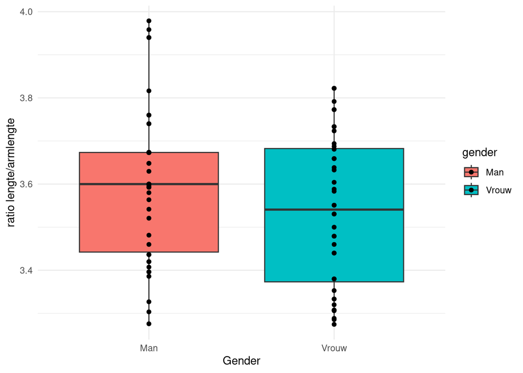

Uit de plot komt dat er geen groot verschil zit tussen de ratios, maar het blijkt wel dat mannen vaker even lange armen hebben.

De hypothese is “Er is een verschil tussen de verhouding van armlengte tot lichaamslengte bij mannen en vrouwen.”.

## Reflectie op het experiment

Bespreek in je groep de volgende vragen en voeg de antwoorden toe aan je uitgewerkte onderzoeksdocument.

1. Zijn de metingen tussen de verschillende meters ook (significant) verschillend? Zo ja, waardoor zou je de verschillen kunnen verklaren?

   Nee, de metingen van de twee meters verschillen niet veel. Kleine verschillen komen waarschijnlijk door houding, meetpunt en afronding op hele centimeters.
2. Onderzoek de verschillen tussen mannen en vrouwen met betrekking tot hand lengte, handbreedte en de ratio.

   Voor de ratio zien we wel een klein verschil, maar dat verschil is niet groot.
3. Zou je het protocol aanpassen na deze ervaring, of was hij voldoende duidelijk en reproduceerbaar?

   Het protocol was duidelijk genoeg om het onderzoek uit te voeren, maar we zouden het toch iets aanpassen. Bijvoorbeeld met betere meetafspraken en meten in millimeters in plaats van hele centimeters.